# sjPlot Introduction

## Description

- Providing plotting and table output functions for data visualization. Results of a variety of statistical analyses can be visualized using this package (particularly for people coming from SPSS and/or who are new to R).

## sjPlot functionality

- Reading and writing data from SPSS, SAS and STATA with variable and value labels (e.g., `read_spss`, `write_spss`)
- Providing SPSS-like output for simple description (`sjt.df`), cross tabulated (`sjp.xtab`,`sjt.xtab`), frequencies (`sjp.frq`, `sjt.frq`), histograms, box plots, correlation matrices (`sjt.corr`), PCA (`sjp.pca`, `sjt.pca`), etc.
- Ploting and summarising the outputs for linear regression model with interaction (`sjp.lm`, `sjp.int`, `sjt.lm`), generalized linear regression models (`sjp.glm`) and multilevel regression model (`sjp.lmer`, `sjt.glmer`), etc.

## Installation

```r
# load packages
library(sjPlot)
library(sjmisc)
```

```r
pisa<-read_spss("PISA12-AUS-motivation.sav",
                enc="UTF-8",                # character encoding
                autoAttachVarLabels = TRUE) # attach variable labels
```

- overview your data using `view_spss` and `sjt.df`

```r
view_spss(pisa[,1:8],
          #  showFreq = TRUE,
          #  showPerc = TRUE
)
```

| ID | Name | Label | Values | Value Labels |
| --- | --- | --- | --- | --- |
| 1 | SCHOOLID | School ID 7-digit (region ID + stratum ID + 3-digit school ID) |  |  |
| 2 | Schtype | School type | 1 2 3 | Catholic Government independent |
| 3 | State | State |  |  |
| 4 | StIDStd | Student ID |  |  |
| 5 | Gender | Gender | 0 1 7 8 9 | Female Male N/A Invalid Missing |
| 6 | ST42Q02 | Maths Self-Concept - Not Good at Maths | 1 2 3 4 7 8 9 | Strongly agree Agree Disagree Strongly disagree N/A Invalid Missing |
| 7 | ST42Q04 | Maths Self-Concept - Get Good | 1 2 3 4 7 8 9 | Strongly agree Agree Disagree Strongly disagree N/A Invalid Missing |
| 8 | ST42Q06 | Maths Self-Concept - Learn Quickly | 1 2 3 4 7 8 9 | Strongly agree Agree Disagree Strongly disagree N/A Invalid Missing |

```r
# display data description like 'describe' function in 'psych' package
sjt.df(pisa[,10:15])
```

| Variable | vars | n | missings | missings (percentage) | mean | sd | median | trimmed | mad | min | max | range | skew | kurtosis | se |
| --- | --- | --- | --- | --- | --- | --- | --- | --- | --- | --- | --- | --- | --- | --- | --- |
| ST29Q01 | 1 | 9431 | 5050 | 34.87 | 2.8 | 0.82 | 3 | 2.82 | 1.48 | 1 | 4 | 3 | -0.26 | -0.47 | 0.01 |
| ST29Q03 | 2 | 9412 | 5069 | 35 | 2.62 | 0.86 | 3 | 2.64 | 1.48 | 1 | 4 | 3 | -0.07 | -0.67 | 0.01 |
| ST29Q04 | 3 | 9390 | 5091 | 35.16 | 2.71 | 0.89 | 3 | 2.76 | 1.48 | 1 | 4 | 3 | -0.26 | -0.67 | 0.01 |
| ST29Q06 | 4 | 9407 | 5074 | 35.04 | 2.45 | 0.86 | 2 | 2.44 | 1.48 | 1 | 4 | 3 | 0.09 | -0.63 | 0.01 |
| ST29Q02 | 5 | 9424 | 5057 | 34.92 | 1.86 | 0.75 | 2 | 1.78 | 0 | 1 | 4 | 3 | 0.72 | 0.44 | 0.01 |
| ST29Q05 | 6 | 9421 | 5060 | 34.94 | 1.84 | 0.76 | 2 | 1.75 | 0 | 1 | 4 | 3 | 0.83 | 0.68 | 0.01 |

```r
# print correlation
sjt.corr(pisa[,20:28],
         missingDeletion = "pairwise",
         pvaluesAsNumbers = TRUE,  # FALSE: significant levels are indicated by asterisks
         showPValues = TRUE       # show exact pvalues
         #triangle = "lower"      # print the values in the lower triangle of the table
         # val.rm = 0.1           # specify a value where correlation values are not printed to the table
)
```

|  | Instrumental Motivation for Mathematics | Mathematics Interest | Mathematics Behaviour | Mathematics Self-Efficacy | Mathematics Intentions | Mathematics Work Ethic | Openness for Problem Solving | Perseverance | Mathematics Self-Concept |
| --- | --- | --- | --- | --- | --- | --- | --- | --- | --- |
| Instrumental Motivation for Mathematics |  | 0.588 (<.001) | 0.372 (<.001) | 0.368 (<.001) | 0.377 (<.001) | 0.484 (<.001) | 0.304 (<.001) | 0.334 (<.001) | 0.487 (<.001) |
| Mathematics Interest | 0.588 (<.001) |  | 0.499 (<.001) | 0.437 (<.001) | 0.403 (<.001) | 0.571 (<.001) | 0.378 (<.001) | 0.399 (<.001) | 0.663 (<.001) |
| Mathematics Behaviour | 0.372 (<.001) | 0.499 (<.001) |  | 0.410 (<.001) | 0.194 (<.001) | 0.441 (<.001) | 0.418 (<.001) | 0.351 (<.001) | 0.432 (<.001) |
| Mathematics Self-Efficacy | 0.368 (<.001) | 0.437 (<.001) | 0.410 (<.001) |  | 0.157 (<.001) | 0.429 (<.001) | 0.580 (<.001) | 0.469 (<.001) | 0.598 (<.001) |
| Mathematics Intentions | 0.377 (<.001) | 0.403 (<.001) | 0.194 (<.001) | 0.157 (<.001) |  | 0.206 (<.001) | 0.030 (.005) | 0.093 (<.001) | 0.387 (<.001) |
| Mathematics Work Ethic | 0.484 (<.001) | 0.571 (<.001) | 0.441 (<.001) | 0.429 (<.001) | 0.206 (<.001) |  | 0.417 (<.001) | 0.512 (<.001) | 0.510 (<.001) |
| Openness for Problem Solving | 0.304 (<.001) | 0.378 (<.001) | 0.418 (<.001) | 0.580 (<.001) | 0.030 (.005) | 0.417 (<.001) |  | 0.568 (<.001) | 0.528 (<.001) |
| Perseverance | 0.334 (<.001) | 0.399 (<.001) | 0.351 (<.001) | 0.469 (<.001) | 0.093 (<.001) | 0.512 (<.001) | 0.568 (<.001) |  | 0.464 (<.001) |
| Mathematics Self-Concept | 0.487 (<.001) | 0.663 (<.001) | 0.432 (<.001) | 0.598 (<.001) | 0.387 (<.001) | 0.510 (<.001) | 0.528 (<.001) | 0.464 (<.001) |  |
| Computed correlation used spearman-method with pairwise-deletion. |  |  |  |  |  |  |  |  |  |

- print summaries of linear models using `sjt.lm`

```r
# model1: math behavior is predicted by math self-concept, intrinsic value, utility value and gender
model1 <- lm(MATBEH ~ SCMAT + INTMAT + INSTMOT + Gender, data=pisa)
# model2: math work ethic is predicted by math self-concept,intrinsic value, utility value and gender
model2 <- lm(MATWKETH ~ SCMAT + INTMAT + INSTMOT + Gender, data=pisa)
```

```r
sjt.lm(model1, model2)
```

|  | Model 1 |  |  | Model 2 |  |  |
| --- | --- | --- | --- | --- | --- | --- |
|  | B | CI | p | B | CI | p |
| (Intercept) | -0.35 | -0.39 - -0.31 | **<.001** | 0.04 | 0.00 - 0.07 | **.026** |
| Mathematics Self-Concept | 0.20 | 0.16 - 0.24 | **<.001** | 0.29 | 0.25 - 0.32 | **<.001** |
| Mathematics Interest | 0.32 | 0.28 - 0.36 | **<.001** | 0.27 | 0.23 - 0.30 | **<.001** |
| Instrumental Motivation for Mathematics | 0.10 | 0.06 - 0.13 | **<.001** | 0.25 | 0.22 - 0.28 | **<.001** |
| Gender | 0.15 | 0.10 - 0.21 | **<.001** | -0.27 | -0.32 - -0.23 | **<.001** |
| Observations | 4574 |  |  | 4595 |  |  |
| R<sup>2</sup> / adj. R<sup>2</sup> | .265 / .264 |  |  | .398 / .397 |  |  |

```r
# add custom labels and convert to APA output
sjt.lm(model1, model2,
       showHeaderStrings = TRUE,
       stringB = "Estimate",
       showStdBeta = FALSE,
#       stringCI = "Conf. Int.",
       pvaluesAsNumbers = FALSE,
       showStdError = TRUE,
       showConfInt = FALSE,
       stringDependentVariables = "Outcomes",
       stringPredictors = "Predictors",
       labelDependentVariables = c("Math behaviors",
                                  "Math work ethic")
#      CSS = list(css.topcontentborder = "+font-size: 0px;")  # remove intercept
#      remove.estimates = 2  # remove the second coefficient after intercept
       )
```

| *Predictors* | *Outcomes* |  |  |  |
| --- | --- | --- | --- | --- |
|  | Math behaviors |  | Math work ethic |  |
|  | Estimate | std. Error | Estimate | std. Error |
| (Intercept) | -0.35 *** | 0.02 | 0.04 * | 0.02 |
| Mathematics Self-Concept | 0.20 *** | 0.02 | 0.29 *** | 0.02 |
| Mathematics Interest | 0.32 *** | 0.02 | 0.27 *** | 0.02 |
| Instrumental Motivation for Mathematics | 0.10 *** | 0.02 | 0.25 *** | 0.02 |
| Gender | 0.15 *** | 0.03 | -0.27 *** | 0.02 |
| Observations | 4574 |  | 4595 |  |
| R<sup>2</sup> / adj. R<sup>2</sup> | .265 / .264 |  | .398 / .397 |  |
| Notes | * p<.05 ** p<.01 *** p<.001 |  |  |  |

- plot coefficients of linear model using `sjp.lm`

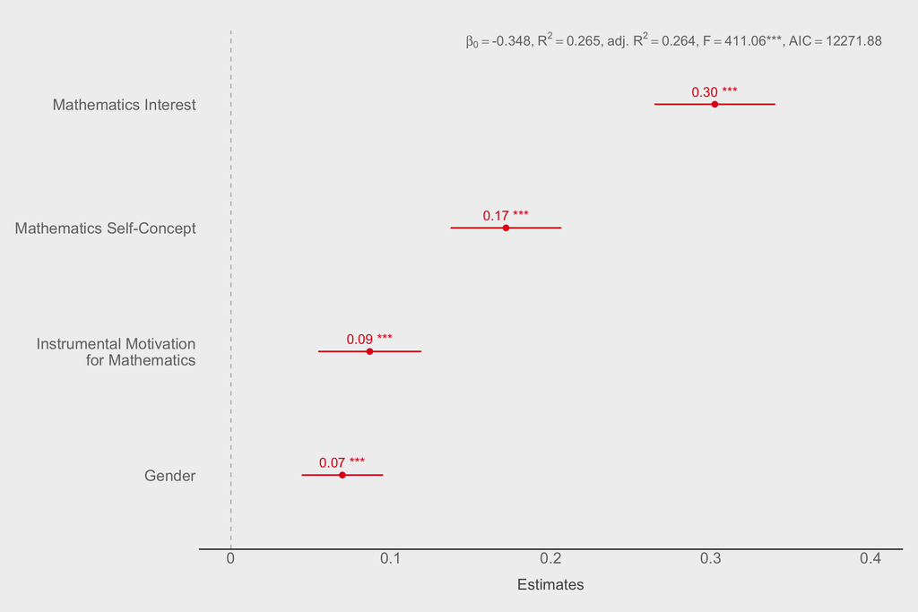

```r
sjp.lm(model1, type = "std") # plot standardized coefficients
```

```r
# testing model assumption including (tests for outliers, multicollinearity, non-normality of residual and outliers, non-normlity of residual, homoscedasticity)
sjp.lm(model1, type = "ma",
       showOriginalModelOnly = FALSE) # FLASE: the following graphical tests will be both applied to the original and to the updated model
# investigate each single predictor of the model
sjp.lm(model1, type = "pred")
```

[output not shown]

- plotting interaction effect using `sjp.int`, which can be used in *lm*, *glm* and *lme4*.[see more examples](http://www.strengejacke.de/sjPlot/sjp.int/)

```r
#install.packages("effects")
```

```r
#Plotting interaction betweenn self-concept and utility value in preiding math work ethic
mod_inter <- lm(scale(MATWKETH) ~ scale(SCMAT)*scale(INSTMOT), data=pisa, x = TRUE)
sjt.lm(mod_inter)
```

|  | Model 1 |  |  |
| --- | --- | --- | --- |
|  | B | CI | p |
| (Intercept) | 0.02 | -0.01 - 0.04 | .198 |
| scale(SCMAT) | 0.38 | 0.35 - 0.40 | **<.001** |
| scale(INSTMOT) | 0.34 | 0.31 - 0.36 | **<.001** |
| scale(SCMAT):scale(INSTMOT) | 0.07 | 0.05 - 0.09 | **<.001** |
| Observations | 4595 |  |  |
| R<sup>2</sup> / adj. R<sup>2</sup> | .358 / .357 |  |  |

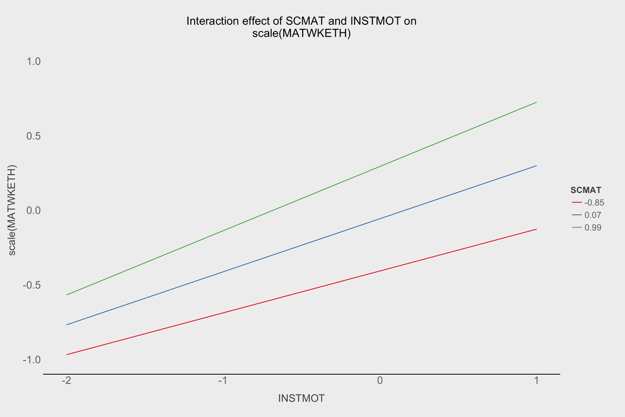

```r
library(effects)
sjp.int(mod_inter, type = "eff",
        #showValueLabels = TRUE, # show value labels
        #showCI = TRUE           # show confidence interval
        moderatorValues = "meansd") #use the mean as well as one standard deviation above and below the mean value.
```

- provide an base-graphic-example for simple-slopes plot

```r
plot.new()
f1<- function(x)(.38)*x+(.34)*(+1)+(.07)*(+1)*x
f2<- function(x)(.38)*x+(.34)*0+(.07)*(0)*x
f3<- function(x)(.38)*x+(.34)*(-1)+(.07)*(-1)*x

plot(f1, from=-1, to=1, lty=1,lwd=3, ylab="MATWKETH (SD)", xlab="SCMAT (SD)", xlim=c(-1,1), ylim=c(-1,1))
plot(f2, from=-1, to=1, lty=3,lwd=3, add=TRUE, ylab="MATWKETH (SD)", xlab="SCMAT (SD)", xlim=c(-1,1), ylim=c(-1,1))
plot(f3, from=-1, to=1, lty=5,lwd=3, add=TRUE, ylab="MATWKETH (SD)", xlab="SCMAT (SD)", xlim=c(-1,1), ylim=c(-1,1))
legend("topleft", lty=c(1,2,3),lwd=c(3,3,3),legend=c('INSTMOT = +1SD','INSTMOT = Mean','INSTMOT = -1SD'))
```

[output not shown]

- summarises odds ratios (forest plots) of generalized linear models using `sjt.glm`

```r
# outcome: ST48Q01 - "Intention to attend Math vs. Language courses after school"
#          ST48Q03 - "Intention to study hard in Math vs. language classes"
model3 <- glm(ST48Q01 ~ SCMAT + INTMAT + INSTMOT + Gender, data=pisa, family = binomial(link = "logit"))
model4 <- glm(ST48Q03 ~ SCMAT + INTMAT + INSTMOT + Gender, data=pisa, family = binomial(link = "logit"))
#summary(fit4)
```

```r
sjt.glm(model3,model4,
        labelDependentVariables = c("Intention to attend Math vs. Language courses after school",
                                    "Intention to study hard in Math vs. language classes"))
```

|  | Intention to attend Math vs. Language courses after school |  |  | Intention to study hard in Math vs. language classes |  |  |
| --- | --- | --- | --- | --- | --- | --- |
|  | OR | CI | p | OR | CI | p |
| (Intercept) | 2.07 | 1.87 - 2.30 | **<.001** | 1.16 | 1.06 - 1.28 | **.002** |
| Mathematics Self-Concept | 0.54 | 0.48 - 0.61 | **<.001** | 0.75 | 0.68 - 0.84 | **<.001** |
| Mathematics Interest | 0.68 | 0.61 - 0.76 | **<.001** | 0.59 | 0.53 - 0.65 | **<.001** |
| Instrumental Motivation for Mathematics | 0.53 | 0.48 - 0.58 | **<.001** | 0.59 | 0.54 - 0.65 | **<.001** |
| Gender | 0.34 | 0.30 - 0.40 | **<.001** | 0.59 | 0.52 - 0.68 | **<.001** |
| Observations | 4188 |  |  | 4254 |  |  |
| Pseudo-R<sup>2</sup> | R<sup>2<sub>CS</sub> = .293 R<sup>2</sup><sub>N</sub> = .390</sup> |  |  | R<sup>2<sub>CS</sub> = .216 R<sup>2</sup><sub>N</sub> = .289</sup> |  |  |

- plot probability curves of predictors using `sjp.glm`

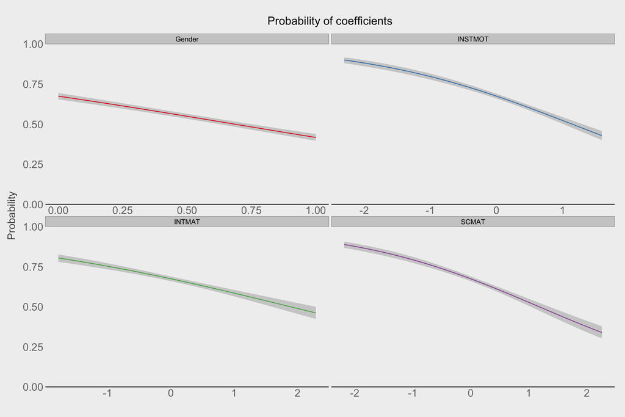

```r
#The odds ratios for continous predictors are a bit more difficult to interpret than categorial variables. Thus, you can also plot probability curves of all predictors (covariates, coefficients)
sjp.glm(model3,
        axisLabels.y = predlab,
        type = "prob",
        show.se = TRUE)
```

* plot ramdon effects of linear mixed effects using `sjp.lmer`

```r
library(lme4)
pisa1 <-pisa[as.numeric(pisa$SCHOOLID) < 21, ] # select the first 20 schools for easy presentation
modelRandomInt <- lmer(MATWKETH ~ SCMAT + INTMAT + INSTMOT + (1|SCHOOLID) , data = pisa1)
summary(modelRandomInt)
```

```
## Linear mixed model fit by REML ['lmerMod']
## Formula: MATWKETH ~ SCMAT + INTMAT + INSTMOT + (1 | SCHOOLID)
##    Data: pisa1
##
## REML criterion at convergence: 271.5
##
## Scaled residuals:
##     Min      1Q  Median      3Q     Max
## -3.5248 -0.5621  0.0257  0.4845  2.1955
##
## Random effects:
##  Groups   Name        Variance Std.Dev.
##  SCHOOLID (Intercept) 0.1010   0.3179
##  Residual             0.5098   0.7140
## Number of obs: 115, groups:  SCHOOLID, 20
##
## Fixed effects:
##             Estimate Std. Error t value
## (Intercept) -0.09361    0.09896  -0.946
## SCMAT        0.18186    0.11207   1.623
## INTMAT       0.19073    0.10863   1.756
## INSTMOT      0.37623    0.10676   3.524
##
## Correlation of Fixed Effects:
##         (Intr) SCMAT  INTMAT
## SCMAT   -0.061
## INTMAT   0.145 -0.459
## INSTMOT -0.075 -0.301 -0.441
```

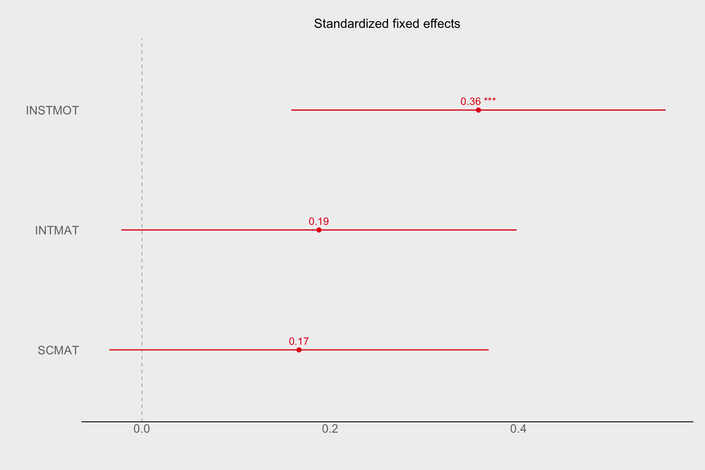

```r
# View standardized fixed effects
sjp.lmer(modelRandomInt, type = "fe.std")
```

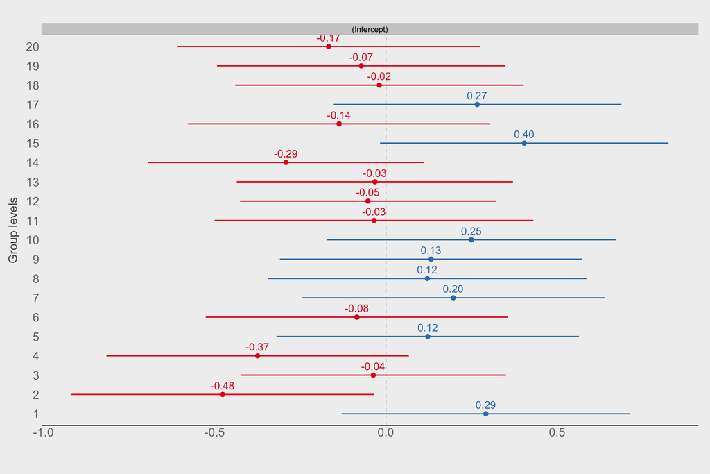

```r
# view random intercept across groups
sjp.lmer(modelRandomInt)
```

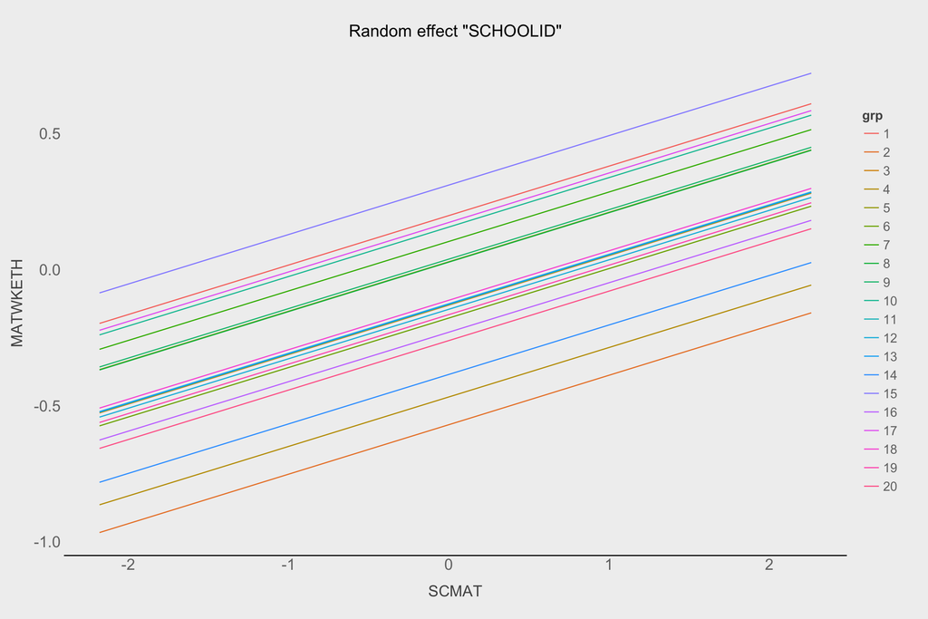

```r
# plot fixed effects depending on group levels
sjp.lmer(modelRandomInt, type = "fe.ri",
        vars = "SCMAT") # only for predictior math self-concept
```

* view ramdom effets of linear mixed effects using `sjp.lmer`

```r
modelRandomSlope <- lmer(MATWKETH ~ SCMAT + INTMAT + INSTMOT + (SCMAT + INTMAT + INSTMOT|SCHOOLID) , data = pisa1)
summary(modelRandomSlope)
```

```
## Linear mixed model fit by REML ['lmerMod']
## Formula:
## MATWKETH ~ SCMAT + INTMAT + INSTMOT + (SCMAT + INTMAT + INSTMOT |
##     SCHOOLID)
##    Data: pisa1
##
## REML criterion at convergence: 267
##
## Scaled residuals:
##      Min       1Q   Median       3Q      Max
## -2.96344 -0.51501  0.02059  0.38995  2.46090
##
## Random effects:
##  Groups   Name        Variance Std.Dev. Corr
##  SCHOOLID (Intercept) 0.06333  0.2517
##           SCMAT       0.03454  0.1859    0.79
##           INTMAT      0.09022  0.3004   -0.10 -0.19
##           INSTMOT     0.19225  0.4385   -0.22  0.02 -0.94
##  Residual             0.42520  0.6521
## Number of obs: 115, groups:  SCHOOLID, 20
##
## Fixed effects:
##             Estimate Std. Error t value
## (Intercept)  -0.1097     0.0906  -1.211
## SCMAT         0.1923     0.1168   1.647
## INTMAT        0.1978     0.1272   1.555
## INSTMOT       0.3942     0.1425   2.767
##
## Correlation of Fixed Effects:
##         (Intr) SCMAT  INTMAT
## SCMAT    0.121
## INTMAT   0.072 -0.426
## INSTMOT -0.132 -0.176 -0.614
```

```r
#Lets compare a random intercept to a random slope model
anova(modelRandomInt, modelRandomSlope)
```

```
## Data: pisa1
## Models:
## modelRandomInt: MATWKETH ~ SCMAT + INTMAT + INSTMOT + (1 | SCHOOLID)
## modelRandomSlope: MATWKETH ~ SCMAT + INTMAT + INSTMOT + (SCMAT + INTMAT + INSTMOT |
## modelRandomSlope:     SCHOOLID)
##                  Df    AIC    BIC  logLik deviance Chisq Chi Df Pr(>Chisq)
## modelRandomInt    6 271.88 288.35 -129.94   259.88
## modelRandomSlope 15 285.90 327.07 -127.95   255.90 3.979      9     0.9128
```

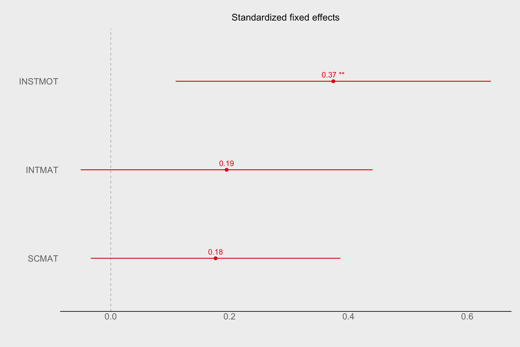

```r
# view standardized fixed effects
sjp.lmer(modelRandomSlope, type = "fe.std")
```

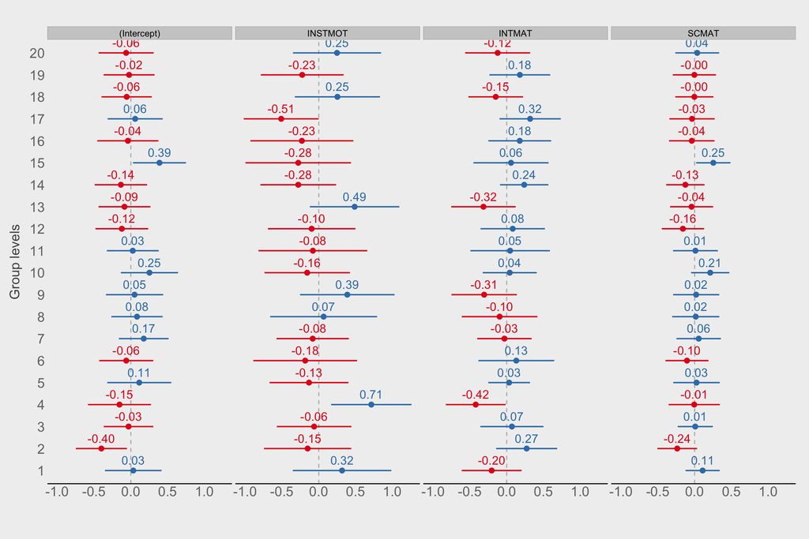

```r
# View random effects across groups
sjp.lmer(modelRandomSlope)
```

* note: random splopes can not be plotted in this version

[figure not shown]

```r
# creat a function to plot random slopes
visualize.lme <- function (model, coefficient, group, ...){
  r <- ranef(model)[[group]]
  f <- fixef(model)

  effects <- data.frame(r[,1]+f[1], r[,2]+f[2])

  number.lines <- nrow(effects)

  predictor.min <- tapply(model@frame[[coefficient]], model@frame[[group]], min, na.rm=TRUE)
  predictor.max <- tapply(model@frame[[coefficient]], model@frame[[group]], max, na.rm=TRUE)

  outcome.min <- min(predict(model), na.rm=TRUE)
  outcome.max <- max(predict(model), na.rm=TRUE)

  plot (c(min(predictor.min),max(predictor.max)),c(outcome.min,outcome.max), type="n", ...)

  for (i in 1:number.lines){
    expression <- function(x) {effects[i,1] + (effects[i,2] * x) }
    curve(expression, from=predictor.min[i], to=predictor.max[i], add=TRUE)
  }
}

visualize.lme(modelRandomSlope, "INSTMOT", "SCHOOLID",
              xlab="Math workethic", ylab="Utility value",
              main="Effect of utility value on work ethic stratified by school")
```

```r
# we need to specify the items which are used in PCA
sjt.pca(pisa[,c(6:17)],
        numberOfFactors = 3,
        showVariance=TRUE)
```

Principal Component Analysis (with varimax rotation)

|  | Component 1 | Component 2 | Component 3 |
| --- | --- | --- | --- |
| Maths Self-Concept - Not Good at Maths | -0.21 | 0.22 | 0.80 |
| Maths Self-Concept - Get Good | 0.19 | -0.22 | -0.80 |
| Maths Self-Concept - Learn Quickly | 0.29 | -0.15 | -0.80 |
| Maths Self-Concept - One of Best Subjects | 0.43 | -0.17 | -0.72 |
| Maths Interest - Enjoy Reading | 0.78 | -0.24 | -0.26 |
| Maths Interest - Look Forward to Lessons | 0.81 | -0.28 | -0.25 |
| Maths Interest - Enjoy Maths | 0.82 | -0.27 | -0.35 |
| Maths Interest - Interested | 0.73 | -0.40 | -0.31 |
| Instrumental Motivation - Worthwhile for Work | 0.28 | -0.82 | -0.17 |
| Instrumental Motivation - Worthwhile for Career Chances | 0.23 | -0.84 | -0.22 |
| Instrumental Motivation - Important for Future Study | 0.24 | -0.83 | -0.19 |
| Instrumental Motivation - Helps to Get a Job | 0.24 | -0.83 | -0.18 |
| Proportion of Variance | 56.28 % | 12.83 % | 8.05 % |
| Cumulative Proportion | 56.28 % | 69.11 % | 77.16 % |
| Cronbach’s α | 0.91 | 0.90 | -0.06 |

## References and Recourse

- [djPlot reference manual and vignettes](http://cran.r-project.org/web/packages/sjPlot/sjPlot.pdf)
- [Documentation and examples](http://www.strengejacke.de/sjPlot/)
- [sjPlot GitHub repo](https://github.com/sjPlot/devel)
- [sjmisc GitHub repo](https://github.com/sjPlot/sjmisc)